# ExploratoryDataAnalysis

My wife and I have a (pipe)dream of putting an addition onto our home. The project started out as converting an existing screen porch into a four-season sunroom. The idea has now grown into adding an extra garage stall or two and a new master suite to the back of the house. Ignoring the matter of architectural feasability, all this talk got me thinking. How much is an extra bedroom, bathroomm, ~500 sq ft. and 2 garage stalls worth? How much value would a project of this add to our home. Would the added value offset the costs of construction.

This is the idea that this project was born from. My goal was to build a data scraper to gather real estate listings from the past year for the surrounding neighborhoods. I built the datascraper in R and collected the data from theMLSonline.com on March 9, 2015. There are some limitations to the data set. The website only posts the list price for each property, as opposed to the sales price.

There are better sites out there for this kind of data, but the barrier is higher. I have been working on a webscraper in Python to gather data from the city of Minneapolis' property details database. The data from this website is *much* richer, and will eventually lead to much more interesting results. As of right now I have yet to work the kinks out of this system, and so I am left with my preliminary data set from theMLSonline. What follows is an exploratory analysis of this data.

First things first, lets load the data into a pandas datframe and check the number of rows. Also, lets take a look at the first few lines of the data.

```python
import pandas as pd
listings_df = pd.read_csv('listings.csv')
print listings_df.shape
listings_df.head()
```

```
(1388, 9)
```

|  | address | lotsize | sqft | bthrm | bdrm | frplce | garage | type | listprice |
| --- | --- | --- | --- | --- | --- | --- | --- | --- | --- |
| 0 | 5657 1st Avenue S, Minneapolis, MN 55419 | 0.130 | 1686 | 3 | 3 | 1 | 2 | Single Family | 295000 |
| 1 | 5245 34th Avenue S, Minneapolis, MN 55417 | 0.110 | 1632 | 2 | 3 | 1 | 3 | Single Family | 280000 |
| 2 | 6728 Queen Avenue S, Richfield, MN 55423 | 0.147 | 2095 | 2 | 5 | 0 | 1 | Single Family | 249500 |
| 3 | 5011 Woodlawn Boulevard, Minneapolis, MN 55417 | 0.110 | 1400 | 2 | 4 | 1 | 1 | Single Family | 239900 |
| 4 | 6825 11th Avenue S, Richfield, MN 55423 | 0.180 | 1820 | 3 | 4 | 0 | 1 | Single Family | 209900 |

```python
listings_df.type.unique()
```

```
array(['Single Family'], dtype=object)
```

So we've got 1388 entries with 7 columns with variables and 1 column with all Single Family designations. We can safely drop that column from our analysis as I only included it to ensure that there were no duplexes or other multi-family properties included in the data set.

```python
listings_df = listings_df.drop('type', axis =  1)
listings_df.head()
```

|  | address | lotsize | sqft | bthrm | bdrm | frplce | garage | listprice |
| --- | --- | --- | --- | --- | --- | --- | --- | --- |
| 0 | 5657 1st Avenue S, Minneapolis, MN 55419 | 0.130 | 1686 | 3 | 3 | 1 | 2 | 295000 |
| 1 | 5245 34th Avenue S, Minneapolis, MN 55417 | 0.110 | 1632 | 2 | 3 | 1 | 3 | 280000 |
| 2 | 6728 Queen Avenue S, Richfield, MN 55423 | 0.147 | 2095 | 2 | 5 | 0 | 1 | 249500 |
| 3 | 5011 Woodlawn Boulevard, Minneapolis, MN 55417 | 0.110 | 1400 | 2 | 4 | 1 | 1 | 239900 |
| 4 | 6825 11th Avenue S, Richfield, MN 55423 | 0.180 | 1820 | 3 | 4 | 0 | 1 | 209900 |

```python
listings_df.describe()
```

|  | lotsize | sqft | bthrm | bdrm | frplce | garage | listprice |
| --- | --- | --- | --- | --- | --- | --- | --- |
| count | 1388.000000 | 1388.000000 | 1388.000000 | 1388.000000 | 1388.000000 | 1388.000000 | 1388.000000 |
| mean | 0.172938 | 1899.969020 | 2.065562 | 3.364553 | 0.820605 | 1.657061 | 289757.628963 |
| std | 0.536211 | 586.948823 | 0.765625 | 0.569304 | 0.779297 | 0.662499 | 149192.067682 |
| min | 0.000000 | 450.000000 | 1.000000 | 3.000000 | 0.000000 | 0.000000 | 78800.000000 |
| 25% | 0.120000 | 1519.000000 | 2.000000 | 3.000000 | 0.000000 | 1.000000 | 199000.000000 |
| 50% | 0.150000 | 1802.500000 | 2.000000 | 3.000000 | 1.000000 | 2.000000 | 239900.000000 |
| 75% | 0.200000 | 2132.000000 | 2.000000 | 4.000000 | 1.000000 | 2.000000 | 339900.000000 |
| max | 20.000000 | 6499.000000 | 6.000000 | 7.000000 | 3.000000 | 12.000000 | 1349000.000000 |

A quick look at the data reveals some odd outliers. the lotsize column is in acres, and we can see from the summary data there is a listing with a 20 acre lot. This seems unrealistic for South Minneapolis. Also, the value of 7 bedroom or 12(!) garage houses has little bearing on our 3 bedroom house. I will drop these data points from my analysis, but not before inspecting them.

```python
listings_df[listings_df.lotsize == 20]
```

|  | address | lotsize | sqft | bthrm | bdrm | frplce | garage | listprice |
| --- | --- | --- | --- | --- | --- | --- | --- | --- |
| 861 | 6407 15th Avenue S, Richfield, MN 55423 | 20 | 2300 | 2 | 3 | 1 | 2 | 219900 |

I looked the address up on Zillow and it looks like a very normal sized yard. I will set the lotsize equal to the median lotsize for all the data.

```python
listings_df = listings_df.set_value(861, 'lotsize', .15)
listings_df.irow(861)
```

```
address      6407 15th Avenue S, Richfield, MN 55423
lotsize                                         0.15
sqft                                            2300
bthrm                                              2
bdrm                                               3
frplce                                             1
garage                                             2
listprice                                     219900
Name: 861, dtype: object
```

```python
listings_df[listings_df.garage == 12]
```

|  | address | lotsize | sqft | bthrm | bdrm | frplce | garage | listprice |
| --- | --- | --- | --- | --- | --- | --- | --- | --- |
| 182 | 7141 Oak Grove Boulevard, Richfield, MN 55423 | 0.5 | 2523 | 2 | 5 | 1 | 12 | 424900 |

```python
listings_df = listings_df.drop(182, axis = 0)
listings_df.describe()
```

|  | lotsize | sqft | bthrm | bdrm | frplce | garage | listprice |
| --- | --- | --- | --- | --- | --- | --- | --- |
| count | 1387.000000 | 1387.000000 | 1387.000000 | 1387.000000 | 1387.000000 | 1387.000000 | 1387.000000 |
| mean | 0.158391 | 1899.519827 | 2.065609 | 3.363374 | 0.820476 | 1.649603 | 289660.193944 |
| std | 0.061727 | 586.921817 | 0.765899 | 0.567811 | 0.779563 | 0.601650 | 149201.695094 |
| min | 0.000000 | 450.000000 | 1.000000 | 3.000000 | 0.000000 | 0.000000 | 78800.000000 |
| 25% | 0.120000 | 1519.000000 | 2.000000 | 3.000000 | 0.000000 | 1.000000 | 199000.000000 |
| 50% | 0.150000 | 1802.000000 | 2.000000 | 3.000000 | 1.000000 | 2.000000 | 239900.000000 |
| 75% | 0.200000 | 2131.500000 | 2.000000 | 4.000000 | 1.000000 | 2.000000 | 339850.000000 |
| max | 0.528000 | 6499.000000 | 6.000000 | 7.000000 | 3.000000 | 4.000000 | 1349000.000000 |

Let's also only consider 3, 4 or 5 bedroom houses in our analysis, and let's take a look at the scatter plot of list price versus square footage.

```python
threefourfive = listings_df[listings_df.bdrm < 6]
threefourfive.describe()
```

|  | lotsize | sqft | bthrm | bdrm | frplce | garage | listprice |
| --- | --- | --- | --- | --- | --- | --- | --- |
| count | 1382.000000 | 1382.000000 | 1382.000000 | 1382.000000 | 1382.000000 | 1382.000000 | 1382.000000 |
| mean | 0.157929 | 1889.750362 | 2.057164 | 3.353111 | 0.817656 | 1.648336 | 287525.245297 |
| std | 0.061186 | 561.082029 | 0.752733 | 0.541996 | 0.777140 | 0.602368 | 144863.483649 |
| min | 0.000000 | 450.000000 | 1.000000 | 3.000000 | 0.000000 | 0.000000 | 78800.000000 |
| 25% | 0.120000 | 1519.000000 | 2.000000 | 3.000000 | 0.000000 | 1.000000 | 198925.000000 |
| 50% | 0.150000 | 1800.500000 | 2.000000 | 3.000000 | 1.000000 | 2.000000 | 239900.000000 |
| 75% | 0.200000 | 2125.500000 | 2.000000 | 4.000000 | 1.000000 | 2.000000 | 339000.000000 |
| max | 0.528000 | 5424.000000 | 6.000000 | 5.000000 | 3.000000 | 4.000000 | 1349000.000000 |

Let's visualize the data by looking at a scatter plot of listprice and square footage with the linear regression line included. Note: the statsmodels.api linear regression requires a column of ones included with the regressor data in order to find an intercept.

```python
import numpy as np

threefourfive.ones = 1
firstmodel = pd.ols(y=threefourfive.listprice, x=threefourfive.sqft)
print firstmodel
```

```
-------------------------Summary of Regression Analysis-------------------------

Formula: Y ~ <x> + <intercept>

Number of Observations:         1382
Number of Degrees of Freedom:   2

R-squared:         0.5743
Adj R-squared:     0.5740

Rmse:          94554.0252

F-stat (1, 1380):  1861.5407, p-value:     0.0000

Degrees of Freedom: model 1, resid 1380

-----------------------Summary of Estimated Coefficients------------------------
      Variable       Coef    Std Err     t-stat    p-value    CI 2.5%   CI 97.5%
--------------------------------------------------------------------------------
             x   195.6560     4.5348      43.15     0.0000   186.7678   204.5441
     intercept -82215.6885  8939.0998      -9.20     0.0000 -99736.3242 -64695.0529
---------------------------------End of Summary---------------------------------
```

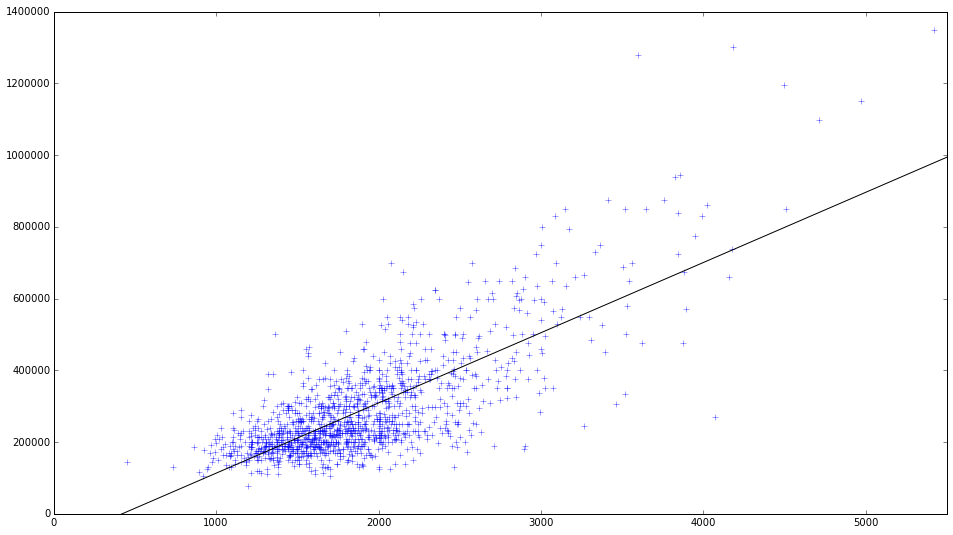

```python
%matplotlib inline
import matplotlib.pyplot as plt

slope = 195.66
intercept = -82215.69

x0 = np.arange(0, 5550, 50)
y0 = intercept + slope * x0
plt.figure(figsize = [16, 9])
plt.plot(threefourfive.sqft, threefourfive.listprice, '+', alpha=.7)
plt.plot(x0, y0, 'k-')
plt.xlim((0, 5500))
plt.ylim((0, 1400000))
plt.show()
```

Let's make our plot display a little more information and zoom in a little bit...

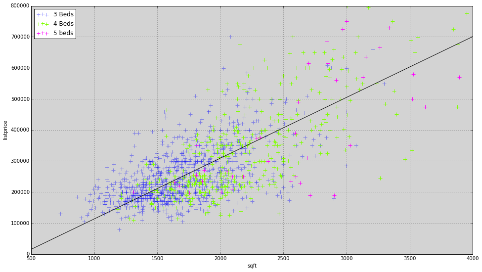

```python
ax = threefourfive[threefourfive.bdrm == 3].plot(x='sqft', y ='listprice', marker='+', s=50, alpha=.4, kind = 'scatter', color = 'Blue', xlim=[500, 4000], ylim=[0, 800000], figsize=[16, 9], label='3 Beds')
threefourfive[threefourfive.bdrm == 4].plot(x='sqft', y ='listprice', s=50, marker= '+', color='Chartreuse', kind = 'scatter', label = '4 Beds', ax=ax)
threefourfive[threefourfive.bdrm == 5].plot(x='sqft', y ='listprice',s=50, marker= '+', color = 'Magenta', kind = 'scatter', label = '5 beds', ax=ax)
plt.legend(loc='upper left')
plt.plot(x0, y0, 'k')
ax.set_axis_bgcolor('LightGrey')
ax.grid()
```

I've made the 3 bedroom datapoints transparent with the alpha keyword. It looks like there might be some non-linear behavior of `sqft` on `listprice`. Now let's check to see if the model should include a quadratic term.

```python
threefourfive.insert(3, 'sqftsquared', sqft**2)
sqftsquared = threefourfive.sqftsquared
sqft = threefourfive.sqft

secondmodel = pd.ols(y=threefourfive.listprice, x={'sqftsquared':sqftsquared, 'sqft':sqft})
print secondmodel
coeffs = secondmodel.beta.values
```

```
-------------------------Summary of Regression Analysis-------------------------

Formula: Y ~ <sqft> + <sqftsquared> + <intercept>

Number of Observations:         1382
Number of Degrees of Freedom:   3

R-squared:         0.6117
Adj R-squared:     0.6112

Rmse:          90331.8601

F-stat (2, 1379):  1086.3228, p-value:     0.0000

Degrees of Freedom: model 2, resid 1379

-----------------------Summary of Estimated Coefficients------------------------
      Variable       Coef    Std Err     t-stat    p-value    CI 2.5%   CI 97.5%
--------------------------------------------------------------------------------
          sqft   -15.0514    18.7760      -0.80     0.4229   -51.8523    21.7496
   sqftsquared     0.0455     0.0039      11.53     0.0000     0.0378     0.0533
     intercept 139097.7583 21003.4799       6.62     0.0000 97930.9377 180264.5790
---------------------------------End of Summary---------------------------------
```

The p-value for the quadratic term is essentially zero, but the p-value for the linear term has jumped to .42. I'm not sure what to make of that, so I may try a log(listprice) model instead. Lets look at a plot of our new model.

```python
y0 = coeffs[0]*x0 + coeffs[1] * x0**2 + coeffs[2]
```

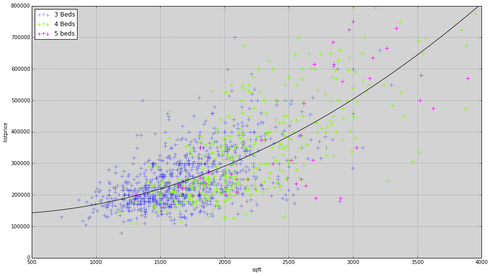

```python
ax = threefourfive[threefourfive.bdrm == 3].plot(x='sqft', y ='listprice', marker='+', s=50, alpha=.4, kind = 'scatter', color = 'Blue', xlim=[500, 4000], ylim=[0, 800000], figsize=[16, 9], label='3 Beds')
threefourfive[threefourfive.bdrm == 4].plot(x='sqft', y ='listprice', s=50, marker= '+', color='Chartreuse', kind = 'scatter', label = '4 Beds', ax=ax)
threefourfive[threefourfive.bdrm == 5].plot(x='sqft', y ='listprice',s=50, marker= '+', color = 'Magenta', kind = 'scatter', label = '5 beds', ax=ax)
plt.legend(loc='upper left')
plt.plot(x0, y0, 'k')
ax.set_axis_bgcolor('LightGrey')
ax.grid()
```

```python
try:
    threefourfive.insert(9, 'loglistprice', np.log(threefourfive.listprice))
except:
    pass

loglistprice = threefourfive.loglistprice
print '---------------------Summary Statistics of Modified Dataframe-------------------'
print threefourfive.describe()

logmodel = pd.ols(y=loglistprice, x={'sqft':sqft})
print logmodel
coeffs2 = logmodel.beta.values
```

```
---------------------Summary Statistics of Modified Dataframe-------------------
           lotsize         sqft      sqftsquared        bthrm         bdrm  \
count  1382.000000  1382.000000      1382.000000  1382.000000  1382.000000
mean      0.157929  1889.750362   3885741.678003     2.057164     3.353111
std       0.061186   561.082029   2669338.155596     0.752733     0.541996
min       0.000000   450.000000    202500.000000     1.000000     3.000000
25%       0.120000  1519.000000   2307361.000000     2.000000     3.000000
50%       0.150000  1800.500000   3241800.500000     2.000000     3.000000
75%       0.200000  2125.500000   4517751.000000     2.000000     4.000000
max       0.528000  5424.000000  29419776.000000     6.000000     5.000000

            frplce       garage       listprice  loglistprice
count  1382.000000  1382.000000     1382.000000   1382.000000
mean      0.817656     1.648336   287525.245297     12.476268
std       0.777140     0.602368   144863.483649      0.408970
min       0.000000     0.000000    78800.000000     11.274668
25%       0.000000     1.000000   198925.000000     12.200683
50%       1.000000     2.000000   239900.000000     12.387977
75%       1.000000     2.000000   339000.000000     12.733755
max       3.000000     4.000000  1349000.000000     14.114874

-------------------------Summary of Regression Analysis-------------------------

Formula: Y ~ <sqft> + <intercept>

Number of Observations:         1382
Number of Degrees of Freedom:   2

R-squared:         0.5170
Adj R-squared:     0.5166

Rmse:              0.2843

F-stat (1, 1380):  1476.8683, p-value:     0.0000

Degrees of Freedom: model 1, resid 1380

-----------------------Summary of Estimated Coefficients------------------------
      Variable       Coef    Std Err     t-stat    p-value    CI 2.5%   CI 97.5%
--------------------------------------------------------------------------------
          sqft     0.0005     0.0000      38.43     0.0000     0.0005     0.0006
     intercept    11.4859     0.0269     427.28     0.0000    11.4332    11.5386
---------------------------------End of Summary---------------------------------
```

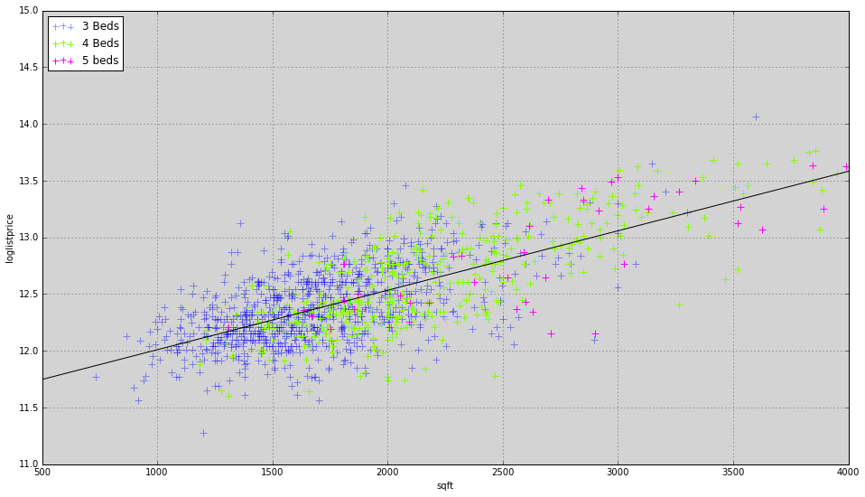

```python
logy0 = coeffs2[0] * x0 + coeffs2[1]
ax = threefourfive[threefourfive.bdrm == 3].plot(x='sqft', y ='loglistprice', marker='+', s=50, alpha=.4, kind = 'scatter', color = 'Blue', xlim=[500, 4000], ylim=[11, 15], figsize=[16, 9], label='3 Beds')
threefourfive[threefourfive.bdrm == 4].plot(x='sqft', y ='loglistprice', s=50, marker= '+', color='Chartreuse', kind = 'scatter', label = '4 Beds', ax=ax)
threefourfive[threefourfive.bdrm == 5].plot(x='sqft', y ='loglistprice',s=50, marker= '+', color = 'Magenta', kind = 'scatter', label = '5 beds', ax=ax)
plt.legend(loc='upper left')
plt.plot(x0, logy0, 'k')
ax.set_axis_bgcolor('LightGrey')
ax.grid()
```

Which model is better? Its hard to say at this point as theory does not really point me in one specific direction. A case could be made for the `loglistprice` model because it is somewhat natural to talk about housing prices in terms of percentages. But one could easily make the argument that dollar increase are also natural. At this point, there is not much else I can say on the matter until I dig deeper into the existing data. I am currently building a web-scraping app that will gather data off of Minneapolis' property details website to analyze and hopefully come up with some deeper insights. In subsequent posts I will include other regressors and see if I can't get a good predictive model for how much value increase an addition would provide.